# Project: Investigate a Dataset ( The Medical Appointment No Shows)

## Introduction

My objective for this project is to analyze [the Medical Appointment No Shows Dataset](https://www.kaggle.com/joniarroba/noshowappointments) and convey my findings using Python libraries NumPy, pandas, Matplotlib, and seaborn. 110k medical appointments were collected in Brazil for this dataset, which examines whether or not patients made it to their appointments.

## Data Description

PatientID-----------> The patient’s identification number

AppointmentID----> The appointment number of the patient

Gender--------------> The Patient's Gender ( Male or Female)

ScheduledDay----->The Patients' appointment dates and times

AppointmentDay--> Patients were to arrive at their appointments at the specified time and date

Age------------------> The patient's age

Neighbourhood---> The hospital's location

Scholarship--------> Inclusion or exclusion of a patient from the Brazilian welfare program (1= True, 0 = False)

Hipertension-------> If the patient is hypertensive.(1= True, 0=False)

Diabetes------------> If the patient is diabetic. (1= True, 0=False)

Alcoholism---------> Whether the patient drinks alcohol. (1= True, 0=False)

Handcap-----------> If the patient is handicapped.(1= True, 0=False)

SMS_received---->if the patient recieved SMS notification. (1= True, 0=False)

No-show-----------> If the patient showed up for their appointment.(1= True, 0=False)

## My questions to answer:

1.What percentage of those who show up for appointments vs those who don't?

2.What are the most important factors to get the patient to his appointment?

```python
# importing all packages and set plots to be embedded inline
import numpy as np
import pandas as pd
import matplotlib.pyplot as plt
import seaborn as sns
from scipy import stats

%matplotlib inline
```

## Data Wrangling

### General Properties

```python
# Load my data:

df = pd.read_csv("noshowappointments-kagglev2-may-2016.csv")

#size of data
df.shape
#showing first five rows
df.head()
```

|  | PatientId | AppointmentID | Gender | ScheduledDay | AppointmentDay | Age | Neighbourhood | Scholarship | Hipertension | Diabetes | Alcoholism | Handcap | SMS_received | No-show |
| --- | --- | --- | --- | --- | --- | --- | --- | --- | --- | --- | --- | --- | --- | --- |
| 0 | 2.987250e+13 | 5642903 | F | 2016-04-29T18:38:08Z | 2016-04-29T00:00:00Z | 62 | JARDIM DA PENHA | 0 | 1 | 0 | 0 | 0 | 0 | No |
| 1 | 5.589980e+14 | 5642503 | M | 2016-04-29T16:08:27Z | 2016-04-29T00:00:00Z | 56 | JARDIM DA PENHA | 0 | 0 | 0 | 0 | 0 | 0 | No |
| 2 | 4.262960e+12 | 5642549 | F | 2016-04-29T16:19:04Z | 2016-04-29T00:00:00Z | 62 | MATA DA PRAIA | 0 | 0 | 0 | 0 | 0 | 0 | No |
| 3 | 8.679510e+11 | 5642828 | F | 2016-04-29T17:29:31Z | 2016-04-29T00:00:00Z | 8 | PONTAL DE CAMBURI | 0 | 0 | 0 | 0 | 0 | 0 | No |
| 4 | 8.841190e+12 | 5642494 | F | 2016-04-29T16:07:23Z | 2016-04-29T00:00:00Z | 56 | JARDIM DA PENHA | 0 | 1 | 1 | 0 | 0 | 0 | No |

There are some errors in columns names and they should be corrected in specific form e.g., (_) instead of spaces

```python
# showing data types of columns:
df.dtypes
```

```
PatientId         float64
AppointmentID       int64
Gender             object
ScheduledDay       object
AppointmentDay     object
Age                 int64
Neighbourhood      object
Scholarship         int64
Hipertension        int64
Diabetes            int64
Alcoholism          int64
Handcap             int64
SMS_received        int64
No-show            object
dtype: object
```

patient_id data type should be int instead of float.

ScheduledDay and AppointmentDay are supposed to be date time so they should not be string i.e., objects

```python
#checking for duplicates
df.duplicated().sum()
```

```
0
```

No dublication

```python
#checking for missing value:
df.isnull().sum()
```

```
PatientId         0
AppointmentID     0
Gender            0
ScheduledDay      0
AppointmentDay    0
Age               0
Neighbourhood     0
Scholarship       0
Hipertension      0
Diabetes          0
Alcoholism        0
Handcap           0
SMS_received      0
No-show           0
dtype: int64
```

No missing values for any variable

```python
# counting number of non-null unique values for each variable
df.nunique()
```

```
PatientId          61744
AppointmentID     110527
Gender                 2
ScheduledDay      103549
AppointmentDay        27
Age                  104
Neighbourhood         81
Scholarship            2
Hipertension           2
Diabetes               2
Alcoholism             2
Handcap                5
SMS_received           2
No-show                2
dtype: int64
```

Looking at the difference between PatientId, AppointmentID and ScheduledDay may mean that there are some patients who have more than one appointment. Counts for Scholarship, Hipertension, Diabetes , Alcoholism , Handcap , SMS_received ,and No-show(specifically) are low.

```python
# to make sure if there are some patients have more than one appointment so I calculate here counts of PatientId

df['PatientId'].value_counts()
```

```
8.221460e+14    88
9.963767e+10    84
2.688610e+13    70
3.353480e+13    65
2.584240e+11    62
                ..
2.367500e+11     1
1.744680e+14     1
7.978390e+12     1
5.595420e+13     1
1.557660e+13     1
Name: PatientId, Length: 61744, dtype: int64
```

Now we can see there are some patients have more than one appointment

```python
#showing descritive statistics of dataset
df.describe()
```

|  | PatientId | AppointmentID | Age | Scholarship | Hipertension | Diabetes | Alcoholism | Handcap | SMS_received |
| --- | --- | --- | --- | --- | --- | --- | --- | --- | --- |
| count | 1.105270e+05 | 1.105270e+05 | 110527.000000 | 110527.000000 | 110527.000000 | 110527.000000 | 110527.000000 | 110527.000000 | 110527.000000 |
| mean | 1.474963e+14 | 5.675305e+06 | 37.088874 | 0.098266 | 0.197246 | 0.071865 | 0.030400 | 0.022248 | 0.321026 |
| std | 2.560949e+14 | 7.129575e+04 | 23.110205 | 0.297675 | 0.397921 | 0.258265 | 0.171686 | 0.161543 | 0.466873 |
| min | 3.920000e+04 | 5.030230e+06 | -1.000000 | 0.000000 | 0.000000 | 0.000000 | 0.000000 | 0.000000 | 0.000000 |
| 25% | 4.172615e+12 | 5.640286e+06 | 18.000000 | 0.000000 | 0.000000 | 0.000000 | 0.000000 | 0.000000 | 0.000000 |
| 50% | 3.173180e+13 | 5.680573e+06 | 37.000000 | 0.000000 | 0.000000 | 0.000000 | 0.000000 | 0.000000 | 0.000000 |
| 75% | 9.439170e+13 | 5.725524e+06 | 55.000000 | 0.000000 | 0.000000 | 0.000000 | 0.000000 | 0.000000 | 1.000000 |
| max | 9.999820e+14 | 5.790484e+06 | 115.000000 | 1.000000 | 1.000000 | 1.000000 | 1.000000 | 4.000000 | 1.000000 |

Here is minus value for age which need to be fixed

## Cleaning and Fixing

### Rename columns

```python
#Fixing errors of column names
df.rename(columns = {'PatientId':'Patient_Id','ScheduledDay':'Scheduled_Day','AppointmentDay':'Appointment_Day','Hipertension': 'Hypertension','Handcap': 'Handicap','No-show':'No_show'}, inplace = True)
df.head()
```

|  | Patient_Id | AppointmentID | Gender | Scheduled_Day | Appointment_Day | Age | Neighbourhood | Scholarship | Hypertension | Diabetes | Alcoholism | Handicap | SMS_received | No_show |
| --- | --- | --- | --- | --- | --- | --- | --- | --- | --- | --- | --- | --- | --- | --- |
| 0 | 2.987250e+13 | 5642903 | F | 2016-04-29T18:38:08Z | 2016-04-29T00:00:00Z | 62 | JARDIM DA PENHA | 0 | 1 | 0 | 0 | 0 | 0 | No |
| 1 | 5.589980e+14 | 5642503 | M | 2016-04-29T16:08:27Z | 2016-04-29T00:00:00Z | 56 | JARDIM DA PENHA | 0 | 0 | 0 | 0 | 0 | 0 | No |
| 2 | 4.262960e+12 | 5642549 | F | 2016-04-29T16:19:04Z | 2016-04-29T00:00:00Z | 62 | MATA DA PRAIA | 0 | 0 | 0 | 0 | 0 | 0 | No |
| 3 | 8.679510e+11 | 5642828 | F | 2016-04-29T17:29:31Z | 2016-04-29T00:00:00Z | 8 | PONTAL DE CAMBURI | 0 | 0 | 0 | 0 | 0 | 0 | No |
| 4 | 8.841190e+12 | 5642494 | F | 2016-04-29T16:07:23Z | 2016-04-29T00:00:00Z | 56 | JARDIM DA PENHA | 0 | 1 | 1 | 0 | 0 | 0 | No |

### Fixing data type

```python
#Fixing data type of Patient_Id

df['Patient_Id']=df['Patient_Id'].apply(np.int64)
df['Patient_Id'].dtypes
```

```
dtype('int64')
```

```python
#Fixing data type of Scheduled_Day and Appointment_Day:

#Scheduled_Day

df['Scheduled_Day']=pd.to_datetime(df['Scheduled_Day'])
df['Scheduled_Day'].dtypes
#Appointment_Day
df['Appointment_Day']=pd.to_datetime(df['Appointment_Day'])
df['Appointment_Day'].dtypes
```

```
datetime64[ns, UTC]
```

### Fixing incorrect data

```python
# finding if there is zero values in Age variable as well as negative ones:

Age=df[df["Age"] <= 0]

Age
```

|  | Patient_Id | AppointmentID | Gender | Scheduled_Day | Appointment_Day | Age | Neighbourhood | Scholarship | Hypertension | Diabetes | Alcoholism | Handicap | SMS_received | No_show |
| --- | --- | --- | --- | --- | --- | --- | --- | --- | --- | --- | --- | --- | --- | --- |
| 59 | 71844300000000 | 5638545 | F | 2016-04-29 08:08:43+00:00 | 2016-04-29 00:00:00+00:00 | 0 | CONQUISTA | 0 | 0 | 0 | 0 | 0 | 0 | No |
| 63 | 236623000000000 | 5628286 | M | 2016-04-27 10:46:12+00:00 | 2016-04-29 00:00:00+00:00 | 0 | SÃO BENEDITO | 0 | 0 | 0 | 0 | 0 | 0 | No |
| 64 | 188517000000000 | 5616082 | M | 2016-04-25 13:28:21+00:00 | 2016-04-29 00:00:00+00:00 | 0 | ILHA DAS CAIEIRAS | 0 | 0 | 0 | 0 | 0 | 1 | No |
| 65 | 271882000000000 | 5628321 | M | 2016-04-27 10:48:50+00:00 | 2016-04-29 00:00:00+00:00 | 0 | CONQUISTA | 0 | 0 | 0 | 0 | 0 | 0 | No |
| 67 | 86471300000000 | 5639264 | F | 2016-04-29 08:53:02+00:00 | 2016-04-29 00:00:00+00:00 | 0 | NOVA PALESTINA | 0 | 0 | 0 | 0 | 0 | 0 | No |
| ... | ... | ... | ... | ... | ... | ... | ... | ... | ... | ... | ... | ... | ... | ... |
| 110345 | 147395000000000 | 5702537 | F | 2016-05-16 12:30:58+00:00 | 2016-06-01 00:00:00+00:00 | 0 | RESISTÊNCIA | 0 | 0 | 0 | 0 | 0 | 0 | No |
| 110346 | 5577530000000 | 5777724 | M | 2016-06-06 14:22:34+00:00 | 2016-06-08 00:00:00+00:00 | 0 | RESISTÊNCIA | 0 | 0 | 0 | 0 | 0 | 0 | No |
| 110454 | 614246000000 | 5772400 | F | 2016-06-03 15:18:44+00:00 | 2016-06-03 00:00:00+00:00 | 0 | RESISTÊNCIA | 0 | 0 | 0 | 0 | 0 | 0 | No |
| 110460 | 43218500000000 | 5769545 | F | 2016-06-03 08:56:51+00:00 | 2016-06-03 00:00:00+00:00 | 0 | RESISTÊNCIA | 0 | 0 | 0 | 0 | 0 | 0 | No |
| 110507 | 476946000000000 | 5786918 | F | 2016-06-08 09:04:18+00:00 | 2016-06-08 00:00:00+00:00 | 0 | MARIA ORTIZ | 0 | 0 | 0 | 0 | 0 | 0 | No |

3540 rows × 14 columns

```python
#Fixing ages that are <= 0
df.drop(Age.index, inplace=True)
df[df["Age"] <= 0]
```

|  | Patient_Id | AppointmentID | Gender | Scheduled_Day | Appointment_Day | Age | Neighbourhood | Scholarship | Hypertension | Diabetes | Alcoholism | Handicap | SMS_received | No_show |
| --- | --- | --- | --- | --- | --- | --- | --- | --- | --- | --- | --- | --- | --- | --- |

All zero and neative values are dropped

### Handling data

```python
#reassigning the values of the no_show column to 0 or 1 instead of No or yes to prevent confusion
df['No_show']= df['No_show'].replace(["No"], 1)
df['No_show']= df['No_show'].replace(["Yes"], 0)

#to confirm the change
df.No_show.value_counts()
```

```
1    85307
0    21680
Name: No_show, dtype: int64
```

```python
#adding column for showed and not showed to use in plots
showed = df['No_show'] == 1
not_showed = df['No_show'] ==0
df['showed'] = showed
df['not_showed'] = not_showed
df.head()
```

|  | Patient_Id | AppointmentID | Gender | Scheduled_Day | Appointment_Day | Age | Neighbourhood | Scholarship | Hypertension | Diabetes | Alcoholism | Handicap | SMS_received | No_show | showed | not_showed |
| --- | --- | --- | --- | --- | --- | --- | --- | --- | --- | --- | --- | --- | --- | --- | --- | --- |
| 0 | 29872500000000 | 5642903 | F | 2016-04-29 18:38:08+00:00 | 2016-04-29 00:00:00+00:00 | 62 | JARDIM DA PENHA | 0 | 1 | 0 | 0 | 0 | 0 | 1 | True | False |
| 1 | 558998000000000 | 5642503 | M | 2016-04-29 16:08:27+00:00 | 2016-04-29 00:00:00+00:00 | 56 | JARDIM DA PENHA | 0 | 0 | 0 | 0 | 0 | 0 | 1 | True | False |
| 2 | 4262960000000 | 5642549 | F | 2016-04-29 16:19:04+00:00 | 2016-04-29 00:00:00+00:00 | 62 | MATA DA PRAIA | 0 | 0 | 0 | 0 | 0 | 0 | 1 | True | False |
| 3 | 867951000000 | 5642828 | F | 2016-04-29 17:29:31+00:00 | 2016-04-29 00:00:00+00:00 | 8 | PONTAL DE CAMBURI | 0 | 0 | 0 | 0 | 0 | 0 | 1 | True | False |
| 4 | 8841190000000 | 5642494 | F | 2016-04-29 16:07:23+00:00 | 2016-04-29 00:00:00+00:00 | 56 | JARDIM DA PENHA | 0 | 1 | 1 | 0 | 0 | 0 | 1 | True | False |

```python
# Verifying the unique number from "Neighbourhood"
df['Neighbourhood'].nunique()
```

```
81
```

## Exploratory Data Analysis

### Q1 (What percentage of those who show up for appointments vs those who don't?)

```python
# Function to plot percentage distribuiton
def pie_plot(df, list_labels, title, title_fontsize=None):
    """
    Input DataFrame, list of labels and title and return pie plot.
    Opcional Input: fontsize title.
    """
    (df.value_counts(normalize=True) * 100).plot.pie(autopct='%1.0f%%', labels=list_labels)
    plt.title(title, fontsize=title_fontsize);
```

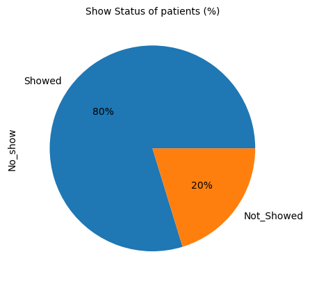

```python
pie_plot(df['No_show'], ['Showed', 'Not_Showed'], 'Show Status of patients (%)', title_fontsize=10)
```

Most patients showed up for their appointments (80%) while (20%)did not show up.

### Q2 (What are the most important factors to get the patient to his appointment?)

#### To assess the age as predictor variable:

```python
#mean of age of who showed
df.Age[showed].mean()
#mean of age who do not showed
df.Age[not_showed].mean()
```

```
35.329151291512915
```

```python
# Function of plot distribuiton of diff.factors
def Factor_distribution(df, column, ylabel,xlabel_fontsize=None,title_fontsize=None):
    """
    Input DataFrame and name of column and return history plot.
    Opcional Input: fontsize from xlabel, ylabel and title.
    """
    plt.hist(df);
    plt.ylabel('Num. of showed patients')
    plt.title('Distribution patients’s number by {}'.format(column), fontsize=title_fontsize)
    plt.xlabel('{}'.format(column), fontsize=xlabel_fontsize);
```

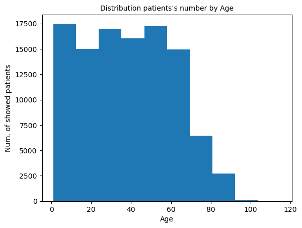

```python
# Age distribution
Factor_distribution(df['Age'], 'Age', 'Num. of showed patients',xlabel_fontsize=10,title_fontsize=10)
```

#### Assessing the special conditions as predector factors

```python
# total number of special conditions for each patient
df['number_of_conditions'] = df.Hypertension + df.Diabetes + df.Alcoholism + df.Handicap

# empty dictionary
conditions_dict = {}

#  no show patientspercentage who had hypertension only
conditions_dict['Hypertension'] = (df[df.number_of_conditions <= 1].groupby('Hypertension').No_show.mean() * 100)[1]
# no show patients percentage who had  diabetes only
conditions_dict['Diabetes'] = (df[df.number_of_conditions <= 1].groupby('Diabetes').No_show.mean() * 100)[1]
# no show patients percentage who had alcoholism only
conditions_dict['Alcoholism'] = (df[df.number_of_conditions <= 1].groupby('Alcoholism').No_show.mean() * 100)[1]
# no show patients percentage who had handicapped only
conditions_dict['Handicapped'] = (df[df.number_of_conditions <= 1].groupby('Handicap').No_show.mean() * 100)[1]

# no show patients percentage who had multiple conditions
conditions_dict['Multiple Conditions'] = df[df.number_of_conditions > 1].No_show.mean() * 100

conditions_dict
```

```
{'Hypertension': 82.9832394056942,
 'Diabetes': 79.64205816554811,
 'Alcoholism': 78.35587929240374,
 'Handicapped': 79.85280588776449,
 'Multiple Conditions': 82.34103357942367}
```

```python
# converting the dictionary to a pandas series
cond_series = pd.Series(conditions_dict)
# sorting the values in descending order
cond_series.sort_values(ascending=False, inplace=True)
cond_series
```

```
Hypertension           82.983239
Multiple Conditions    82.341034
Handicapped            79.852806
Diabetes               79.642058
Alcoholism             78.355879
dtype: float64
```

[figure not shown]

```python
# plot a bar chart
plt.figure(figsize = [9, 3])
plt.bar(x = cond_series.index, height = cond_series,color= ['tan','navajowhite','pink','gray'])
plt.title('No showing rate for each special condition')
plt.ylabel('No Show Percentage');
```

As demonstrated here there are small differences between the percentage of each condition.

### Now we can assess each condition to show real difference:

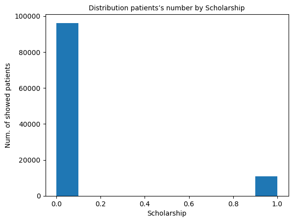

```python
#  Scholarship distribution
Factor_distribution(df['Scholarship'], 'Scholarship','Num. of showed patients', xlabel_fontsize=10, title_fontsize=10)
```

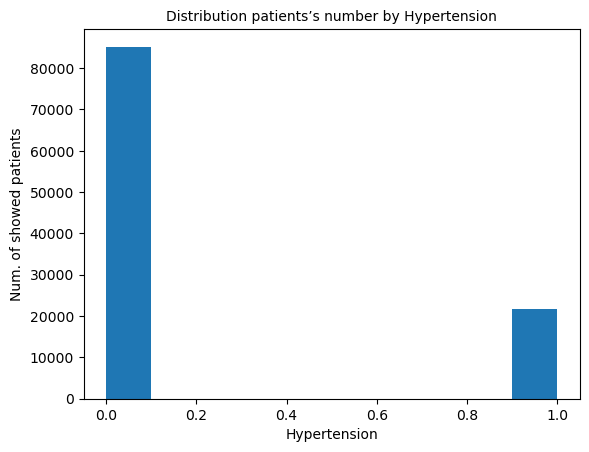

```python
#Hypertension distribution
Factor_distribution(df['Hypertension'], 'Hypertension','Num. of showed patients', xlabel_fontsize=10, title_fontsize=10)
```

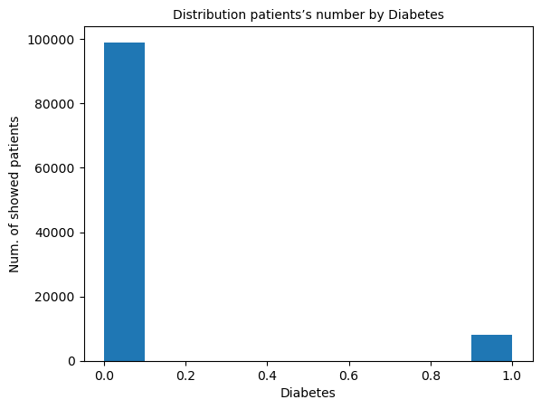

```python
#Diabetes distribution
Factor_distribution(df['Diabetes'], 'Diabetes','Num. of showed patients', xlabel_fontsize=10, title_fontsize=10)
```

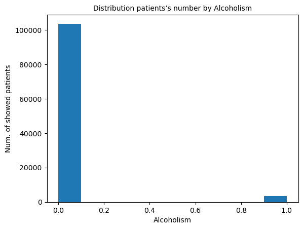

```python
# Alcoholism distribution
Factor_distribution(df['Alcoholism'], 'Alcoholism','Num. of showed patients', xlabel_fontsize=10, title_fontsize=10)
```

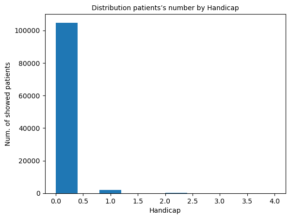

```python
#Handicap distribution
Factor_distribution(df['Handicap'], 'Handicap', 'Num. of showed patients', xlabel_fontsize=10, title_fontsize=10)
```

As demonstrated here most of the data for Scholarship, Hipertension, Diabetes, Alcoholism, and Handcap has a value of 0.

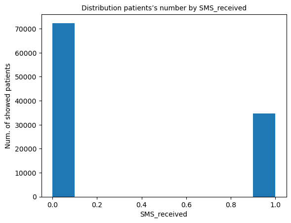

```python
# SMS_received distribution
Factor_distribution(df['SMS_received'], 'SMS_received', 'Num. of showed patients', xlabel_fontsize=10, title_fontsize=10)
```

As shown here at least 50% did not receive SMS.

[figure not shown]

```python
#top 5 neighberhood
(df['Neighbourhood'].value_counts(normalize=False)).head(5).plot(kind='bar')
plt.title('Top 10 number of patients in Neighbourhood', fontsize=10);
```

### assessing the correlation between the variables

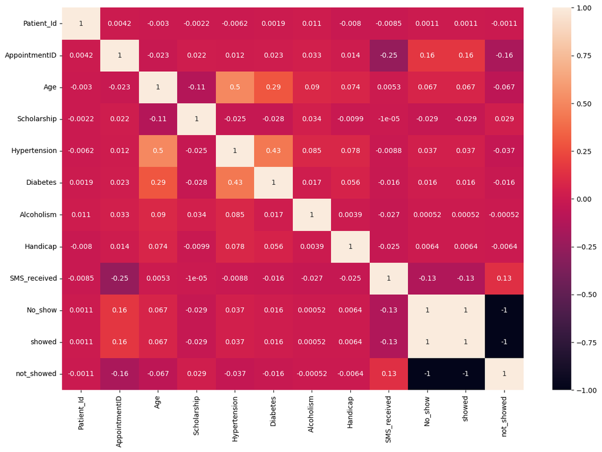

```python
#by using heatmap:
fig, ax = plt.subplots(figsize=(15,10))
sns.heatmap(df.corr(), ax=ax, annot=True);
```

We can see here some correlation between Age and Hypertention so we can make sure by the next scatter blot

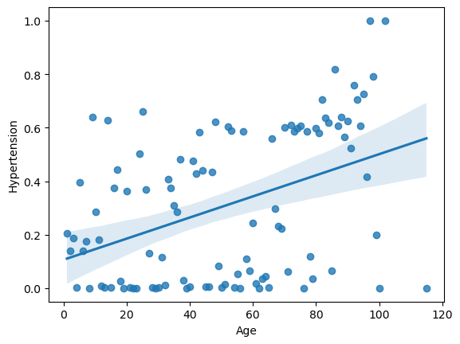

```python
hypertension_mean = df['Hypertension'].groupby(df['Age']).mean()
ages = df['Age'].unique()
sns.regplot(x = ages, y = hypertension_mean)
plt.xlabel('Age')
plt.show()
```

### assessing proportion of appointments of patients for two variables(e.g. age and scholarship)

```python
# function to plot proportion of appointments of patients for two variables(e.g. age and scholarship)
def bar_plot(xdata, ydata, gxlabel, gylabel, gtitle, gerrwidth=None, gpalette=None):
    plt.figure(figsize=(30,8))
    g = sns.barplot(x = xdata, y = ydata, errwidth = gerrwidth, palette = gpalette)
    g.set(xlabel = gxlabel, ylabel = gylabel, title = gtitle)
    return g
```

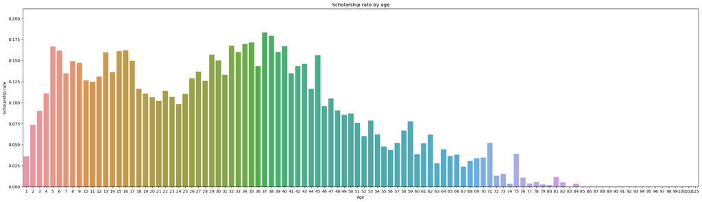

```python
# proportion of appointments of patients on scholarship by age

bar_plot(df['Age'], df['Scholarship'], 'Age', 'Scholarship rate', 'Scholarship rate by age', 0)
plt.show()
```

Based on the plot, it is possible that the scholarship is mostly directed towards youngsters and their parents.

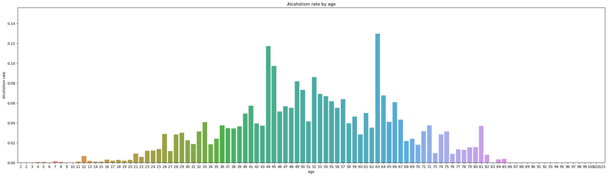

```python
# proportion of appointments of patients on alcholoism by age

bar_plot(df['Age'], df['Alcoholism'], 'Age', 'Alcoholism rate', 'Alcoholism rate by age', 0)
plt.show()
```

Based on this plot Patients in their 40s and 60s are the most vulnerable.

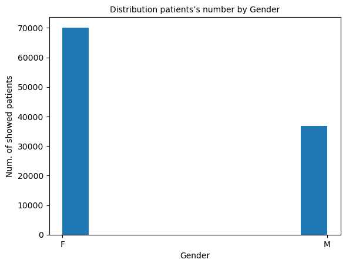

```python
#assessing gender
Factor_distribution(df['Gender'], 'Gender', 'Num. of showed patients', xlabel_fontsize=10, title_fontsize=10)
```

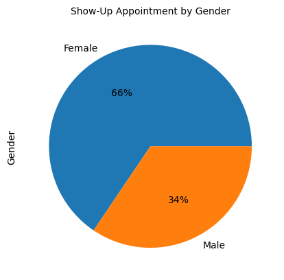

```python
pie_plot(df['Gender'], ['Female', 'Male'], 'Show-Up Appointment by Gender', title_fontsize=10)
```

As showen females account for more than half of all patients.

## limitations:

1. We need assess more features that can affect the showing up rate e.g., economic status , educational level.
2. We need more data thata cover wider area and are up to date.